# Reproducible Research: Peer Assessment 1

Justin R. Papreck

## Loading and preprocessing the data

First, dplyr is used throughout the processing, and is opened in the library. The data is read defining the characters “NA” for missing values, and then filtered out. The format of the date is changed from a character string to “Date”

```r
library(dplyr)
```

```r
library(ggplot2)
activity <- read.csv("./repdata%2Fdata%2Factivity/activity.csv", header = TRUE, na.strings = "NA")
activity <- filter(activity, steps !="NA")
activity$date <- as.Date(activity$date)
```

## What is mean total number of steps taken per day?

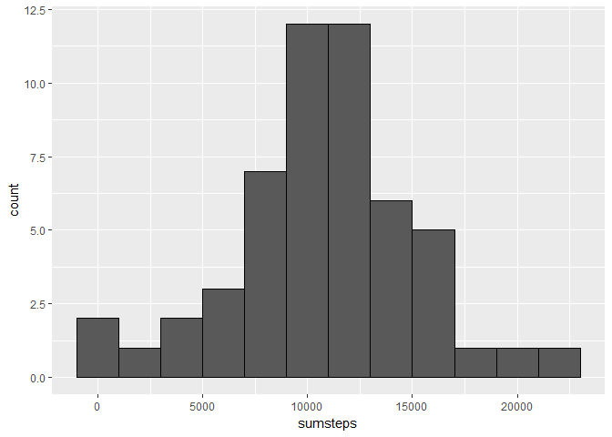

```r
activity_sums <- activity %>% group_by(date) %>% summarise(sumsteps = sum(steps), meansteps = mean(steps), medsteps = median(steps[steps>0]))
h <- ggplot(activity_sums, aes(sumsteps)) + geom_histogram(binwidth = 2000, col=I("black"))
print(h)
```

```r
png(file = "Hist1.png", width = 480, height = 480, units = "px")
print(h)
dev.off()
```

```r
print(mean(activity_sums$sumsteps))
```

```
## [1] 10766.19
```

```r
print(median(activity_sums$sumsteps))
```

```
## [1] 10765
```

## What is the average daily activity pattern?

In these analyses, the data were grouped and observed by interval time throughout the day, where interval 0 represents 12am, and data were collected every 5 minutes following until 11:55pm. The maximum mean number of steps in any given interval was printed along with the corresponding interval number.

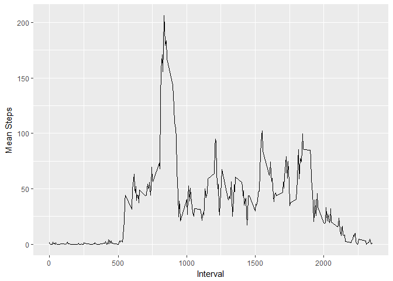

```r
int_times <- activity %>% group_by(interval) %>% summarise(meanints = mean(steps), medianints = median(steps))
g <- ggplot(int_times, aes(interval, meanints)) + geom_line() + labs(x = "Interval", y = "Mean Steps")
print(g)
```

```r
png(file = "int_times.png", width = 480, height = 480, units = "px")
print(g)
dev.off()
```

```r
max_interval <- filter(int_times, meanints == max(int_times$meanints))
print(max_interval)
```

```
## # A tibble: 1 x 3
##   interval meanints medianints
##      <int>    <dbl>      <int>
## 1      835 206.1698         19
```

## Imputing missing values

The original data is brought up again, but this time the NA values are imputed rather than ignored. The number of rows with NA values recorded is first shown. The NA values will be replaced with the Median value of each interval.

```r
Imputer <- read.csv("./repdata%2Fdata%2Factivity/activity.csv", header = TRUE, na.strings = "NA")
print(sum(is.na(Imputer)))
```

```
## [1] 2304
```

```r
Imputer <- Imputer %>% group_by(interval) %>% mutate(steps = ifelse(is.na(steps), median(steps, na.rm = TRUE), steps))
print(sum(is.na(Imputer)))
```

```
## [1] 0
```

The new dataset “Imputer” is a copy of the original data, which then uses the median of each interval group to replace the number of steps for all NA values. Prior to this, the number of NA values was printed, and then confirmed as ‘0’ following the data impute.

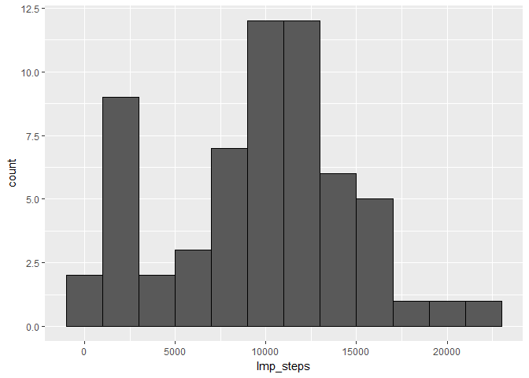

```r
Imputer_D <- Imputer %>% group_by(date) %>% summarise(Imp_steps = sum(steps))
h <- ggplot(Imputer_D, aes(Imp_steps)) + geom_histogram(binwidth = 2000, col=I("black"))
print(h)
```

```r
png(file = "Hist2.png", width = 480, height = 480, units = "px")
print(h)
dev.off()
```

```r
print(mean(Imputer_D$Imp_steps))
```

```
## [1] 9503.869
```

```r
print(median(Imputer_D$Imp_steps))
```

```
## [1] 10395
```

These Values differ from those obtained when not imputing the data. In both cases of mean and median, the values obtained after imputing data were lower than those where all NA values were ignored. The impact suggests that the number of daily steps is lower than what was originally calculated, which could have been impacted by a few days with extremely high values.

## Are there differences in activity patterns between weekdays and weekends?

Initially, we can add a new column to the Imputer file adding the weekday of each date. Then the weekdays and weekends are subsetted into their own dataframes and then re-bound into a dataframe called Week, which is then called up on to plot.

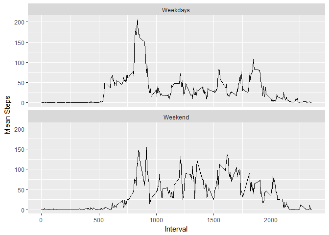

```r
Imputer$date <- as.Date(Imputer$date)
Imputer <- mutate(Imputer, weekday = weekdays(date))
weekdays <- subset(Imputer, Imputer$weekday != "Saturday" & Imputer$weekday !="Sunday")
weekend <- subset(Imputer, Imputer$weekday == "Saturday" | Imputer$weekday =="Sunday")

int_end <- weekend %>% group_by(interval) %>% summarise(mean_ints = mean(steps), median_ints = median(steps))
int_end <- mutate(int_end, type = "Weekend")
int_week <- weekdays %>% group_by(interval) %>% summarise(mean_ints = mean(steps), median_ints = median(steps))
int_week <- mutate(int_week, type = "Weekdays")
Week <- rbind(int_week, int_end)

g <- ggplot(Week, aes(x = interval, y = mean_ints))
g <- g + geom_line() + labs(x = "Interval", y = "Mean Steps") + facet_wrap(~type, nrow=2)
print(g)
```

```r
png(file = "Week.png", width = 480, height = 480, units = "px")
print(g)
dev.off()
```

As the data shows, there appears to be a difference between the weekday and weekend distributions. While the both weekday and weekend plots show the same general interval spike in the morning, the spike on the weekdays has a higher mean, though, throughout the weekend, the mean number of steps appears higher.